# What Can you Do with Machine Learning? slides

```python
HTML('<blockquote class="twitter-tweet"><p lang="en" dir="ltr">Actually, no <a href="https://twitter.com/springerpub?ref_src=twsrc%5Etfw">@springerpub</a>, that&#39;s not Viridis. Someone butchered the online figure processing (PDF is OK). &quot;Chasing Rainbows: A Color-Theoretic Framework for Improving and Preserving Bad Colormaps&quot; <a href="https://t.co/USMkeQAdsD">https://t.co/USMkeQAdsD</a> <a href="https://t.co/zwETyXMVzB">pic.twitter.com/zwETyXMVzB</a></p>&mdash; Stefan van der Walt (@stefanvdwalt) <a href="https://twitter.com/stefanvdwalt/status/1166023380048306177?ref_src=twsrc%5Etfw">August 26, 2019</a></blockquote> <script async src="https://platform.twitter.com/widgets.js" charset="utf-8"></script>')
```

> Actually, no [@springerpub](https://twitter.com/springerpub?ref_src=twsrc%5Etfw), that's not Viridis. Someone butchered the online figure processing (PDF is OK). "Chasing Rainbows: A Color-Theoretic Framework for Improving and Preserving Bad Colormaps" https://t.co/USMkeQAdsD [pic.twitter.com/zwETyXMVzB](https://t.co/zwETyXMVzB)

> — Stefan van der Walt (@stefanvdwalt) [August 26, 2019](https://twitter.com/stefanvdwalt/status/1166023380048306177?ref_src=twsrc%5Etfw)

```python
HTML('<blockquote class="twitter-tweet"><p lang="en" dir="ltr">It&#39;s hard to let go ¯\_(ツ)_/¯ <a href="https://t.co/JWA41x1WNM">https://t.co/JWA41x1WNM</a> One of the weirder things I&#39;ve seen on the Google AI blog.</p>&mdash; Stefan van der Walt (@stefanvdwalt) <a href="https://twitter.com/stefanvdwalt/status/1167536735141515264?ref_src=twsrc%5Etfw">August 30, 2019</a></blockquote> <script async src="https://platform.twitter.com/widgets.js" charset="utf-8"></script>')
```

> It's hard to let go ¯\_(ツ)_/¯ https://t.co/JWA41x1WNM One of the weirder things I've seen on the Google AI blog.

> — Stefan van der Walt (@stefanvdwalt) [August 30, 2019](https://twitter.com/stefanvdwalt/status/1167536735141515264?ref_src=twsrc%5Etfw)

```python
IFrame('https://ai.googleblog.com/2019/08/turbo-improved-rainbow-colormap-for.html', width=1000, height=1000)
```

[interactive chart not shown]

# What is Machine Learning?

Everyone write down their own definition

- “Machine Learning at its most basic is the practice of using algorithms to parse data, learn from it, and then make a determination or prediction about something in the world.” – Nvidia
- “Machine learning is based on algorithms that can learn from data without relying on rules-based programming.”- McKinsey & Co.
- “The field of Machine Learning seeks to answer the question “How can we build computer systems that automatically improve with experience, and what are the fundamental laws that govern all learning processes?” – Carnegie Mellon University
- Machine learning research is part of research on artificial intelligence, seeking to provide knowledge to computers through data, observations and interacting with the world. That acquired knowledge allows computers to correctly generalize to new settings.
- “Machine Learning is the science of getting computers to learn and act like humans do, and improve their learning over time in autonomous fashion, by feeding them data and information in the form of observations and real-world interactions.”

# Machine Learning Basic Concepts

## Representations

- A set of classifers or the language that a computer understands
- How the model connects data to the objective

**The way humans make inference from data is different than machines**

Examples:

- K-nearest neighbors
- support vector machines
- decision trees
- neural networks
- ...

## Evaluation

- how the model determines its success at completing an objective

**The ways humans and computers quantify success at an objective is very different**

Examples:

- accuracy/error rate
- squared error
- likelihood
- k-l divergence (entropy between two distributions)
- ...

# Optimization

- the model search method
- how the model improves itself
- how the model values exploration vs. exploitation

**The way that humans and computers optimize and solve problems is very different**

Examples: Combinatorial optimization

- random search
- greedy search Continuous optimization
- gradient descent
- quasi-Newton method

[figure not shown]

```python
IFrame(src='http://www.r2d3.us/visual-intro-to-machine-learning-part-1/', width=1000, height=800)
```

[interactive chart not shown]

# How we get machines to learn

- Choose the best learning algorithm

Other things that matter

- Collect and collate meaningful data
- Provide the data to the machine in a form that emphasizes the learning objective

**It is not just about solving problems or doing thing. Machines that learn are useful to humans because with all of their processing power they are able to highlight patterns in big data that would have otherwise been missed**

# Challenges and Limitations

## Overfitting

[figure not shown]

- It is possible to get perfect accuracy on a test set but have no ability to conduct inference on a new problem
- The model is not **generalizable**

I can classify types of apples but show me an orange and I am useless

# Overfitting Example with Polynomials

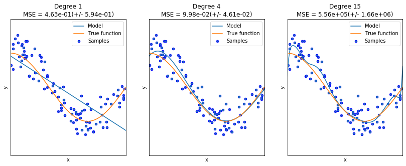

```python
# Defines the function
def true_fun(X):
    return np.cos(1.5 * np.pi * X)


# sets a random seed for consistent plotting
np.random.seed(0)

# sets the number of samples
n_samples = 100
# Sets the range in degrees
degrees = [1, 4, 15]

# adds some noise to the data
X = np.sort(np.random.rand(n_samples))
y = true_fun(X) + np.random.randn(n_samples) * 0.3

# does the plotting
plt.figure(figsize=(14, 5))

# Loops around the number of degrees selected
for i in range(len(degrees)):

    # makes the subplot
    ax = plt.subplot(1, len(degrees), i + 1)
    plt.setp(ax, xticks=(), yticks=())

    # creates the polynomial
    polynomial_features = PolynomialFeatures(degree=degrees[i],
                                             include_bias=False)

    # Least squares linear regression
    linear_regression = LinearRegression()

    # estabilishes a fitting pipeline
    pipeline = Pipeline([("polynomial_features", polynomial_features),
                         ("linear_regression", linear_regression)])

    # does the fit
    pipeline.fit(X[:, np.newaxis], y)

    # Evaluate the models using crossvalidation
    scores = cross_val_score(pipeline, X[:, np.newaxis], y,
                             scoring="neg_mean_squared_error", cv=10)

    # Defines a linear vector
    X_test = np.linspace(0, 1, 100)

    # plots the real model
    plt.plot(X_test, pipeline.predict(X_test[:, np.newaxis]), label="Model")
    plt.plot(X_test, true_fun(X_test), label="True function")

    # plots the generated data
    plt.scatter(X, y, edgecolor='b', s=20, label="Samples")

    # sets the axies format
    plt.xlabel("x")
    plt.ylabel("y")
    plt.xlim((0, 1))
    plt.ylim((-2, 2))
    plt.legend(loc="best")
    plt.title("Degree {}\nMSE = {:.2e}(+/- {:.2e})".format(
        degrees[i], -scores.mean(), scores.std()))
```

# Problems with Generalization

## Overfitting

- Your model is way more complex than the problem you have

# A Simple Linear Neural Network

## Conducting a linear fit with a single layer Neural Network

```python
# Real function
def linear_model(x):
    return 3*x + 7


# defines a vector and generates data with random noise
x = np.linspace(0, 10, 10)
y = linear_model(x) + np.random.randn(len(x)) * 1

# Builds a class for defining a simple linear neural network


class Model:

    def __init__(self, input_dim, dirName):
        self.model = Sequential()

        self.model.add(Dense(1, activation='relu', input_dim=input_dim))
        self.model.compile(loss='mse', optimizer='adam', metrics=['accuracy'])
        self.dirName = dirName

        try:
            # Create target Directory
            os.mkdir(dirName)
            print("Directory ", dirName,  " Created ")
        except FileExistsError:
            print("Directory ", dirName,  " already exists")

    def train(self, x_train, y_train, epochs=101, save_imgs=True):
        for epoch in np.arange(1, epochs):
            self.model.fit(x_train, y_train, batch_size=128)

            if save_imgs:
                if epoch % 10 == 0:
                    plt.plot(x_train, y_train, 'o')
                    x_predict = np.linspace(
                        np.min(x_train), np.max(x_train), 100)
                    plt.plot(x_predict, self.model.predict(x_predict))
                    plt.axis([
                        x_train.min() - 0.5, x_train.max() + 0.5,
                        y_train.min() - 0.5, y_train.max() + 0.5,
                    ])
                    plt.title(f"Epoch #{epoch}")
                    plt.savefig(self.dirName + f"/plot_{epoch:04d}.png")
                    plt.clf()


new_model = Model(1, 'linear_fit')
new_model.train(x, y, epochs=10000)
make_movie('./linear_fit/', './linear_fit/linear_fit.mp4', 30)
```

[output not shown]

```
Directory  linear_fit  already exists
```

[output not shown]

## Conducting a linear fit with a single layer Neural Network

```python
HTML('<iframe width="560" height="315" src="https://www.youtube.com/embed/wa15HLi4kMI" frameborder="0" allow="accelerometer; autoplay; encrypted-media; gyroscope; picture-in-picture" allowfullscreen></iframe>')
```

[video not shown]

## What do you think happens when we make this network wider and deeper?

## Linear Fitting with a Deep Neural Network

```python
class Model:

    def __init__(self, input_dim, dirName):

        # builds a deeper NN
        self.model = Sequential()
        self.model.add(Dense(40, activation='relu', input_dim=input_dim))
        self.model.add(Dense(40, activation='relu'))
        self.model.add(Dense(40, activation='relu'))
        self.model.add(Dense(40, activation='relu'))
        self.model.add(Dense(40, activation='relu'))
        self.model.add(Dense(40, activation='relu'))
        self.model.add(Dense(1,  activation='linear'))
        self.model.compile(loss='mse', optimizer='adam', metrics=['accuracy'])
        self.dirName = dirName

        # Makes the directory to save the files
        try:
            # Create target Directory
            os.mkdir(dirName)
            print("Directory ", dirName,  " Created ")
        except FileExistsError:
            print("Directory ", dirName,  " already exists")

    def train(self, x_train, y_train, epochs=101, save_imgs=True):
        for epoch in np.arange(1, epochs):
            self.model.fit(x_train, y_train, batch_size=128)

            if save_imgs:
                plt.plot(x_train, y_train, 'o')
                x_predict = np.linspace(np.min(x_train), np.max(x_train), 100)
                plt.plot(x_predict, self.model.predict(x_predict))
                plt.axis([
                    x_train.min() - 0.5, x_train.max() + 0.5,
                    y_train.min() - 0.5, y_train.max() + 0.5,
                ])
                plt.title(f"Epoch #{epoch}")
                plt.savefig(self.dirName + f"/plot_{epoch:04d}.png")
                plt.clf()
```

```python
new_model = Model(1, 'deep_linear_fit')
new_model.train(x,y, epochs = 1000)
make_movie('./deep_linear_fit/', './deep_linear_fit/deep_linear_fit.mp4', 20)
```

## Linear Fitting with a Deep Neural Network

```python
HTML('<iframe width="800" height="600" src="https://www.youtube.com/embed/j3hMh7hzTic" frameborder="0" allow="accelerometer; autoplay; encrypted-media; gyroscope; picture-in-picture" allowfullscreen></iframe>')
```

[video not shown]

# Application to more complex functions

## Linear fit to a sine

### What will happen if we train a single layer neural network on a data following a sine function?

### Code

```python
# Function to make a sine function
def sine(x):
    return np.sin(x)

# creates a linear space vector from -3 to 3
x = np.linspace(-3,3,25)
# adds some random noise to the sine function
y = sine(x) + np.random.randn(len(x)) * 0.15
```

```
Directory  linear_fit  already exists
```

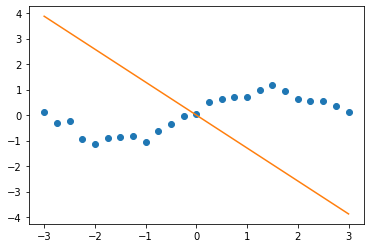

```python
class Model:

    def __init__(self, input_dim, dirName):
        self.model     = Sequential()

        self.model.add(Dense(1, activation='linear', input_dim=input_dim))
        self.model.compile(loss='mse', optimizer='adam', metrics=['accuracy'])
        self.dirName = dirName

        try:
            # Create target Directory
            os.mkdir(dirName)
            print("Directory " , dirName ,  " Created ")
        except FileExistsError:
            print("Directory " , dirName ,  " already exists")



    def train(self, x_train, y_train, epochs=101, save_imgs=True):
        for epoch in np.arange(1, epochs):
            self.model.fit(x_train, y_train, batch_size=128)

            if save_imgs:
                if epoch % 10 == 0:
                    plt.plot(x_train, y_train, 'o')
                    x_predict = np.linspace(np.min(x_train),np.max(x_train),100)
                    plt.plot(x_predict, self.model.predict(x_predict))
                    plt.axis([
                       x_train.min() - 0.5, x_train.max() + 0.5,
                       y_train.min() - 0.5, y_train.max() + 0.5,
                    ])
                    plt.title(f"Epoch #{epoch}")
                    plt.savefig(self.dirName + f"/plot_{epoch:04d}.png")
                    plt.clf()

# Defines the model
new_model = Model(1, 'linear_fit')

# Trains the model
new_model.train(x,y, epochs = 1, save_imgs = False)
plt.plot(x, y, 'o')

# computes the prediction
x_predict = np.linspace(np.min(x),np.max(x),100)
plt.plot(x_predict, new_model.model.predict(x_predict))
```

# What happens when we make this network deeper?

### Code

```python
class Model:

    def __init__(self, input_dim, dirName):
        self.model     = Sequential()

        self.model.add(Dense(40, activation='relu', input_dim=input_dim))
        self.model.add(Dense(40, activation='relu'))
        self.model.add(Dense(40, activation='relu'))
        self.model.add(Dense(40, activation='relu'))
        self.model.add(Dense(40, activation='relu'))
        self.model.add(Dense(40, activation='relu'))
        self.model.add(Dense(1,  activation='linear'))
        self.model.compile(loss='mse', optimizer='adam', metrics=['accuracy'])
        self.dirName = dirName

        try:
            # Create target Directory
            os.mkdir(dirName)
            print("Directory " , dirName ,  " Created ")
        except FileExistsError:
            print("Directory " , dirName ,  " already exists")



    def train(self, x_train, y_train, epochs=101, save_imgs=True):
        for epoch in np.arange(1, epochs):
            self.model.fit(x_train, y_train, batch_size=128)

            if save_imgs:
                plt.plot(x_train, y_train, 'o')
                x_predict = np.linspace(np.min(x_train),np.max(x_train),100)
                plt.plot(x_predict, self.model.predict(x_predict))
                plt.axis([
                   x_train.min() - 0.5, x_train.max() + 0.5,
                   y_train.min() - 0.5, y_train.max() + 0.5,
                ])
                plt.title(f"Epoch #{epoch}")
                plt.savefig(self.dirName + f"/plot_{epoch:04d}.png")
                plt.clf()
```

```
Directory  deep_sine_fit  already exists
```

[output not shown]

[output cut: 85 more lines]

[output not shown]

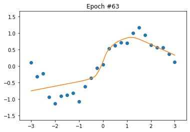

```python
new_model = Model(1, 'deep_sine_fit')
new_model.train(x,y, epochs = 1000)
make_movie('./deep_sine_fit/', './deep_sine_fit/deep_sine_fit.mp4', 20)
```

```python
HTML('<iframe width="800" height="700" src="https://www.youtube.com/embed/P-vVExENCWs" frameborder="0" allow="accelerometer; autoplay; encrypted-media; gyroscope; picture-in-picture" allowfullscreen></iframe>')
```

[video not shown]

# A Very Very Simple Way to Prevent Overfitting

[figure not shown]

### Code for Adding Dropout

```python
class Model:

    def __init__(self, input_dim, dirName):
        self.model     = Sequential()

        self.model.add(Dense(40, activation='relu', input_dim=input_dim))

        self.model.add(Dense(40, activation='relu'))
        self.model.add(Dropout(.4)) #These are dropout layers
        self.model.add(Dense(40, activation='relu'))
        self.model.add(Dropout(.4))
        self.model.add(Dense(40, activation='relu'))
        self.model.add(Dropout(.4))
        self.model.add(Dense(40, activation='relu'))
        self.model.add(Dropout(.4))
        self.model.add(Dense(40, activation='relu'))
        self.model.add(Dense(1,  activation='linear'))
        self.model.compile(loss='mse', optimizer='adam', metrics=['accuracy'])
        self.dirName = dirName

        try:
            # Create target Directory
            os.mkdir(dirName)
            print("Directory " , dirName ,  " Created ")
        except FileExistsError:
            print("Directory " , dirName ,  " already exists")



    def train(self, x_train, y_train, epochs=101, save_imgs=True):
        for epoch in np.arange(1, epochs):
            self.model.fit(x_train, y_train, batch_size=128)

            if save_imgs:
                plt.plot(x_train, y_train, 'o')
                x_predict = np.linspace(np.min(x_train),np.max(x_train),100)
                plt.plot(x_predict, self.model.predict(x_predict))
                plt.axis([
                   x_train.min() - 0.5, x_train.max() + 0.5,
                   y_train.min() - 0.5, y_train.max() + 0.5,
                ])
                plt.title(f"Epoch #{epoch}")
                plt.savefig(self.dirName + f"/plot_{epoch:04d}.png")
                plt.clf()
```

```python
new_model = Model(1, 'deep_sine_fit_dropout')
new_model.train(x,y, epochs = 3000)
make_movie('./deep_sine_fit_dropout/', './deep_sine_fit_dropout/deep_sine_fit_dropout.mp4', 20)
```

[output not shown]

# How Training Looks with Dropout

```python
HTML('<iframe width="800" height="721" src="https://www.youtube.com/embed/oxdv7W9_I4s" frameborder="0" allow="accelerometer; autoplay; encrypted-media; gyroscope; picture-in-picture" allowfullscreen></iframe>')
```

[video not shown]

# Machine learning is just regression in very high dimensional space

# To apply machine learning you need to think about how to structure a real-world objective as an easy to optimize problem

# Modern Demonstrations of Machine learning

## Image Classification

- Convolutional neural networks (CNNs) have shown remarkable performance in image classification

[figure not shown]

# Image Classification

[figure not shown]

# Image Classification

## Feature Vector

[figure not shown]

# Image Classification

## Visualization of the latent space

**Definition: latent space** - a hidden mapping of a data space onto a "latent space" where similar datapoints are grouped together

## Visualization of the latent space

```python
IFrame(src='https://nicola17.github.io/tfjs-tsne-demo/', width=1000, height=1000)
```

[interactive chart not shown]

# This is not just for simple problems

```python
IFrame(src='https://artsexperiments.withgoogle.com/tsnemap/', width=1000, height=1000)
```

[interactive chart not shown]

# Image Classification

## Applicability in Medicine

[figure not shown]

# Identifying object and segmentation

```python
IFrame(src='http://cocodataset.org/#home', width=1000, height=1000)
```

[interactive chart not shown]

# Identifying object and segmentation

[figure not shown]

## Segmentation can be done in real time

```python
IFrame(src='https://2.bp.blogspot.com/-ioaFybzPJ04/WpW3bRaMWdI/AAAAAAAACZM/j4st8tHRYvoW4szUF5ql62dnI6SLhUKQACLcBGAs/s400/image1.gif', width=400, height=400)
```

[interactive chart not shown]

## Segmentation can be done in real time

```python
HTML('<iframe width="900" height="592" src="https://www.youtube.com/embed/JgXVAio8iA8" frameborder="0" allow="accelerometer; autoplay; encrypted-media; gyroscope; picture-in-picture" allowfullscreen></iframe>')
```

[video not shown]

# Segmentation in Materials Science

[figure not shown]

# Image Segmentation in Biology

[figure not shown]

# Natural Language Processing

## Your Amazon Alexa/Siri/Google Assistant

```python
HTML('<iframe width="1231" height="1041" src="https://www.youtube.com/embed/D86YAoynYbA" frameborder="0" allow="accelerometer; autoplay; encrypted-media; gyroscope; picture-in-picture" allowfullscreen></iframe>')
```

[video not shown]

# Natural Language Processing

### Language is a sequence

Models for understanding language can be applied to temporally dependent data

[figure not shown]

### Fake Shakespear Generation

```
VIOLA:
Why, Salisbury must find his flesh and thought
That which I am not aps, not a man and in fire,
To show the reining of the raven and the wars
To grace my hand reproach within, and not a fair are hand,
That Caesar and my goodly father's world;
When I was heaven of presence and our fleets,
We spare with hours, but cut thy council I am great,
Murdered and by thy master's ready there
My power to give thee but so much as hell:
Some service in the noble bondman here,
Would show him to her wine.

KING LEAR:
O, if you were a feeble sight, the courtesy of your law,
Your sight and several breath, will wear the gods
With his heads, and my hands are wonder'd at the deeds,
So drop upon your lordship's head, and your opinion
Shall be against your honour.
```

## This can be done in materials science

[figure not shown]

# Expanding what is language

- Language is just sequential information which conveys information $\rightarrow$ this is the same as spectra

```python
HTML('<iframe width="600" height="150" src="https://www.youtube.com/embed/3dpsd5gTv-8" frameborder="0" allow="accelerometer; autoplay; encrypted-media; gyroscope; picture-in-picture" allowfullscreen></iframe>')
```

[video not shown]

# Generative Models

- When you want to generate an example from a data distribution

### Could be a text Description

[figure not shown]

## Could be a input image or a sketch

[figure not shown]

## Or a live updating semantic map

```python
IFrame(src='http://nvidia-research-mingyuliu.com/gaugan/', width=1400, height=400)
```

[interactive chart not shown]

### Latent Transformations

```python
IFrame(src='https://temporal-cycle-consistency.github.io/assets/mp4/top.mp4', width=1000, height=600)
```

[interactive chart not shown]

# Reinforcement Learning

```python
HTML('<iframe width="900" height="544" src="https://www.youtube.com/embed/Q4bMcUk6pcw" frameborder="0" allow="accelerometer; autoplay; encrypted-media; gyroscope; picture-in-picture" allowfullscreen></iframe>')
```

[video not shown]

## Planning Chemical Synthesis

[figure not shown]